# Tarea_modulo_2

Autores/as

Garcia Rios Santiago

Pérez Maussán Ana Isabel

Roberto

## 1 Efecto de droga en el peso de ratas

Se realiza un estudio para ver el efecto de una droga en el peso de ratas. Se quiere determinar si la droga tiene un impacto en el peso al cabo de tres meses. Para ello, se miden 10 ratas antes y después del tratamiento con la nueva droga. Realiza una comparación entre los pesos (en gramos) antes y después del tratamiento. Revisa cuidadosamente las opciones para realizar pruebas para la comparación de medias de forma que puedas elegir la prueba que mejor contesta a la pregunta de investigación. Menciona la prueba elegida y realízala a mano (calculando un valor crítico y tomando una decisión y también calculando con R un p-value y tomando una decisión). Usa un nivel de significancia de 5%. Interpreta tus resultados. No olvides reportar cuáles son tu hipótesis nula y alternativa.

Los datos de los ratones 1 a 10 son: - antes: 200.1, 190.9, 192.7, 213,241.4, 196.9, 172.2, 185.5, 205.2, 193.7 - después: 392.9, 393.2, 345.1, 393, 434, 427.9, 422, 383.9, 392.3,352.2

**Nota**

**Resumen** Dado que se quiere comparar datos de peso de los mismos individuos, antes y después de la administración de la droga al cabo de 3 meses, la prueba más conveniente es una prueba de t pareada, ya que esta permite hacer una comparación de diferencias de cada uno de los individuos al paso del tiempo o antes y después de un experimento, que en este caso son los tres meses y la administración de la droga. Se calcula una t de tablas (valor crítico a un alfa de 0.05 contemplando dos colas ya que solo queremos saber si hay diferencias y el rechazo puede llegar de cualquiera de los dos lados de la gráfica.

### 1.1 Hipótesis

- Hipótesis nula ($H_0$): La media del peso de las ratas antes del tratamiento es igual a la media del peso de las ratas después del tratamiento. $H_0 : \mu_1 = \mu2$. (mu1 y mu2 corresponden al antes y después)
- Hipótesis alternativa ($H_a$): La media del peso de las ratas antes del tratamiento difiere de la media del peso de las ratas después del tratamiento. $H_a : \mu_1 \neq \mu2$

#### 1.1.1 Prueba estadística

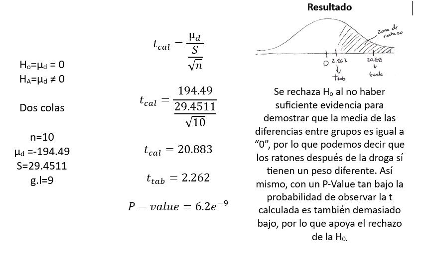

pregunta_1

```r
# Datos
peso_antes <- c(200.1, 190.9, 192.7, 213, 241.4, 196.9, 172.2, 185.5, 205.2, 193.7)
peso_despues <- c(392.9, 393.2, 345.1, 393, 434, 427.9, 422, 383.9, 392.3, 352.2)

n <- length(peso_despues)
gl <- n-1

# Medias
diferencia_medias <- peso_antes - peso_despues
media <- mean(diferencia_medias)

# Desviación estándar para la diferencia de medias
desviacion_estandar <- sd(diferencia_medias)

# Estadístico de t para muestras pareadas
resultado_t_pareada <- (media / (desviacion_estandar/sqrt(n)))

# Valor crítico (t de tablas)
valor_critico <- qt(0.025, 9, lower.tail = TRUE)

# Prueba t muestras pareadas
t_pareada <- t.test(peso_antes, peso_despues,
                              paired = TRUE, # Indica muestras pareadas
                              alternative = "two.sided" # Prueba de dos colas de acuerdo a nuestra H_a
                              )
```

**Conclusión**

La droga parece tener un efecto considerable en aumentar el peso de las ratas durante el periodo de estudio de tres meses.

## 2 Calcular IC para diferencia de medias

Calcula un intervalo de confianza al 95% para la diferencia de las medias a mano. ¿Cómo interpretas el intervalo de confianza? ¿Es congruente tu intepretación del intervalo de confianza con la prueba de hipótesis previa?

**Nota**

**Resumen** Para el resultado obtenido en el análisis, se tiene que el intervalo de confianza va de -215.556 a -173.424, como queremos saber si existe diferencia entre los pesos antes y después de la droga, Ho es Ho=µd = 0, por lo que al estar el 0 fuera del intervalo de confianza podemos sustentar el rechazo de la hipótesis nula siendo esto congruente con el resultado de la prueba de t de muestras pareadas de la pregunta anterior.

#### 2.0.1 Respuesta

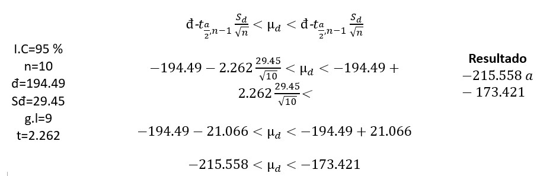

pregunta_2

```r
# Datos
peso_antes <- c(200.1, 190.9, 192.7, 213, 241.4, 196.9, 172.2, 185.5, 205.2, 193.7)
peso_despues <- c(392.9, 393.2, 345.1, 393, 434, 427.9, 422, 383.9, 392.3, 352.2)


# Calcular la diferencia de pesos
diferencia_pesos <-  peso_antes - peso_despues

# Calcular la media y la desviación estándar de las diferencias
media_diferencias <- mean(diferencia_pesos, na.rm = TRUE)
desviacion_est_diferencias <- sd(diferencia_pesos)

# Tamaño de la muestra
n <- length(diferencia_pesos)
gl <- n - 1

# Valor crítico de t para un IC del 95% y n-1 grados de libertad
t_critico <- qt(.975, gl)

# Calcular el intervalo de confianza
margen_error <- t_critico * (desviacion_est_diferencias / sqrt(n))

ic_inferior <- media_diferencias - margen_error
ic_superior <- media_diferencias + margen_error

cat(
  "El intervalo de confianza del 95% para la diferencia de medias es de",
  ic_inferior,
  "a",
  ic_superior
)
```

```
El intervalo de confianza del 95% para la diferencia de medias es de -215.5581 a -173.4219
```

Este intervalo refuerza la conclusión que la droga tiene un efecto en el peso de las ratas.

## 3 Vacaciones en CDMX

Se postula que el número promedio de días que una persona toma de vacaciones al año en oficinas del gobierno de la CDMX es mayor a 15. Se toma una muestra aleatoria del registro de los días de vacaciones de 100 empleados de estas oficinas y se obtiene una media de 18 días con una varianza de 9.5 días. Somete a prueba esta hipótesis (el promedio de vacaciones es mayor a 15 días) a un nivel alfa de 0.05. Realiza la prueba a mano usando valores críticos y también calculando a mano el p-value.

**Nota**

### 3.1 Hipótesis

- Hipótesis nula ($H_0$): El número promedio de días de vacaciones es 15 días o menos. μ≤15.
- Hipótesis alternativa (H1): El número promedio de días de vacaciones es mayor a 15 días. μ>15.

### 3.2 prueba t

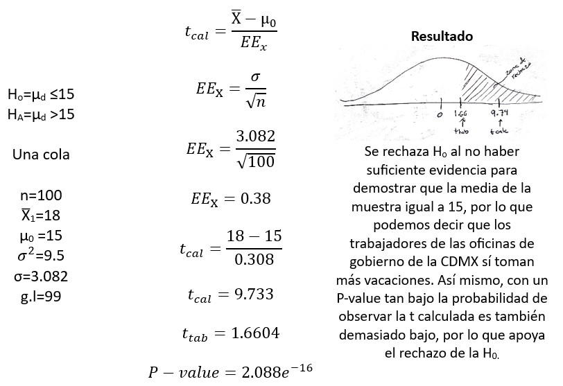

pregunta_3

```r
# Datos
media_muestral <- 18
media_hipotesis_nula <- 15
varianza_muestral <- 9.5
n <- 100

desviacion_estandar_muestra <- varianza_muestral ** 0.5

# Estadístico de t

estadistico_t <- (media_muestral - media_hipotesis_nula) / (desviacion_estandar_muestra / (n ** 0.5))



# p-value (1 cola)
gl <- n - 1

p_value <- pt(estadistico_t, gl, lower.tail = FALSE)

cat("El valor del estadístico de t es:",
    estadistico_t,
    "y el p-value es:",
    p_value
    )
```

```
El valor del estadístico de t es: 9.733285 y el p-value es: 2.08879e-16
```

**Conclusión**

Dado que el valor p es significativamente menor que el nivel de significancia (α=0.05), rechazamos la hipótesis nula. Esto indica que hay evidencia estadísticamente significativa para afirmar que el número promedio de días que una persona toma de vacaciones al año en oficinas del gobierno de la Ciudad de México es mayor a 15 días.

## 4 Loop de números aleatorios

Construye un bucle en R que te permita obtener 10 números aleatorios de distribuciones normales con medias `0, 10, 20 y 30` y los almacene en una LISTA (cada elemento de la lista contiene un vector con los 10 números aleatorios tomados de estas distribuciones normales). *Hint*:deberás buscar la forma de recorrer los elementos de un vector en donde almacenarás las medias de las distribuciones indicadas.

**Nota**

Se puede realiza con un bucle `for` que recorra un vector con las medias `(0, 10, 20, 30)`. Después, en cada iteración, generamos 10 números aleatorios de una distribución normal con la media de la iteración actual `i` y una desviación estándar constante. Al final, los números aleatorios se almacenan en un vector que luego se añade a una lista.

**Tip**

**set.seed** La función `set.seed()` se usa para crear resultados reproducibles cuando usamos código que crea variables aleatorias. Con esta función, nos garantizamos de crear los mismos valores aleatorios cada vez que corramos el script. Se utiliza de la forma:`set.seed(seed)`, donde `seed` es cualquier número.

```r
# Hacer este código reproducible con set.seed()

set.seed(123)

# Hacer un vector con las medias de interés
medias <- c(0, 10, 20, 30)

# Iniciar una lista vacía donde vamos a guardar los vectores con números aleatorios
numeros_aleatorios <- list()

# Loop para generar los números aleatorios con distribución normal
for (i in medias) {
  # Generar 10 números aleatorios con la media actual + distribución normal + desviación estándar de 13 (usar cualquier constante)
  numeros <- rnorm(10, mean = i)

  # Agregar a la lista el vector de números aleatorios
  # Se usa la media (i) como clave para almacenar
  # Con esto podemos acceder a los vectores basados en el valor de la media
  numeros_aleatorios[[as.character(i)]] <- numeros
}

# El resultado es que la variable numeros_aleatorios tiene la lista de vectores con los números aleatorios
```

**Resumen del loop**

1. Hacer un vector con los números deseados (medias).
2. Iniciar una lista vacía (`numeros_aleatorios`). Aquí se van a guardar los vectores de números aleatorios.
3. Usar un `loop for` que itere cada media del vector (del paso 1).
4. Usar `rnorm` para generar 10 números aleatorios de una distribución normal con la media de la iteración actual.
5. Se añaden los números aleatorios que se generaron a la lista `numeros_aleatorios`.
6. Nuestra lista ahora contiene vectores generados a partir de una distribución normal con 10 elementos aleatorios y la media especificada.

## 5 Función de media if-else

Construye una función en R que le devuelva al usuario una media si se introduce una variable continua (con un contenido de valores continuos en dicha variable), o el valor categórico con mayor frecuencia (una especie de moda) si se introduce una variable categórica (la variable categórica contiene valores discretos). Hint: Vas a necesitar utilizar la pareja if-else en tu código

**Nota**

**Resumen de la función**

1. Verificar si la variable introducida es numérica(continua) con `is.numeric(variable)`.
2. Si la variable es numérica, calcula y devuelve su media con `mean(variable)`.
3. Else, si la variable no es numérica (categórica), la función calcula la moda.

```r
funcion_ifelse <- function(variable) {
  if (is.numeric(variable)) {
    # Si la variable es numérica, devuelve la media
    return(cat("Media=", mean(variable, na.rm=TRUE)))
  } else {
    # Si la variable no es numérica, calcula y devuelve la moda
    tabla_frecuencias <- table(variable)
    # valores con la mayor frecuencia en la tabla de frecuencias. which.max() devuelve la posición del primer máximo valor de frecuencia en la tabla, y names() extrae el nombre asociado a esa posición, es decir, el valor más frecuente.
    moda <- names(which.max(tabla_frecuencias))
    return(cat("Moda=", moda))
  }
}

## Comprobación
dec<-c(1.26,2.35,3.56,9.45,10.35,33.5,2.1,3.2)
dec2<-c(1,2,3,4,5,6,6,6,6,7,8,9,9,10,1,2,3,4,5,6,7,8,9)
ent<-c(1L,2L,3L,4L,5L,6L,6L,6L,6L,7L,8L,9L,9L,10L,1L,2L,3L,4L,5L,6L,7L,8L,9L)
cate<-c("pe","ga","ga","to","in","pe","ga")

funcion_ifelse(iris$Sepal.Length)
```

```
Media= 5.843333
```

```r
funcion_ifelse(iris$Species)
```

```
Moda= setosa
```

```r
funcion_ifelse(dec)
```

```
Media= 8.22125
```

```r
funcion_ifelse(ent)
```

```
Media= 5.521739
```

```r
funcion_ifelse(cate)
```

```
Moda= ga
```

## 6 Dimorfismo sexual

Se estudia el dimorfismo sexual en una especie de gecko. Se mide la longitud hocico-cloaca en cm de 10 machos y 8 hembras. ¿Hay diferencias en la longitud entre los sexos usando alfa de 0.05? Aborda esta pregunta mediante un análisis paramétrico y también mediante una prueba de aleatorización. Los datos son: - Machos: `11.3, 11.1, 10.7, 11.0, 12.0, 11.4, 11.2, 11.6, 11.7, 11.7` - Hembras:`11.0, 11.7, 10.5,10.6, 11.1, 11.1, 10.8, 10.7`

**Nota**

**Resumen** De inicio para este análisis se realiza una prueba de t de dos muestras; sin embargo, como se tienen muestras con tamaños diferentes se usa la prueba de Welch. En este sentido, cuando se calcula en R, es necesario incluir en la función que las muestras tienen diferentes tamaños, indicando que var.equal=FALSE. Por otro lado, para realzar la prueba de aleatorización (Monte Carlo), primero se calculó la diferencia de las medias de las dos muestras, después se creó una función que permite hacer el remuestreo y que arroje como resultado la diferencia de las medias de cada remuestreo realizado. Se repitieron los muestreos n veces (obteniendo n diferencias de las medias). Con estos datos se obtiene la distribución nula y finalmente se obtiene el número de resultados del remuestreo que es mayor o igual a la diferencia de medias observadas con el muestreo, teniendo que este valor dividido entre n corresponde al valor P.

### 6.1 Análisis paramétrico

Con análisis paramétrico ($t$ de muestras independientes) podemos comparar la media de dos grupos diferentes.

- Hipótesis nula ($H_0$): No hay diferencia en la media de longitud hocico-cloaca entre machos y hembras. μ machos =μ hembras
- Hipótesis alternativa ($H_a$): Hay una diferencia en la media de longitud hocico-cloaca entre machos y hembras. H1 :μ machos != μ hembras

```r
# Datos
machos <- c(11.3, 11.1, 10.7, 11.0, 12.0, 11.4, 11.2, 11.6, 11.7, 11.7)
hembras <- c(11.0, 11.7, 10.5, 10.6, 11.1, 11.1, 10.8, 10.7)

# Análisis paramétrico: Prueba t de muestras independientes

t.test(machos, hembras, alternative = "two.sided", var.equal = F)
```

```
    Welch Two Sample t-test

data:  machos and hembras
t = 2.3696, df = 15.269, p-value = 0.03139
alternative hypothesis: true difference in means is not equal to 0
95 percent confidence interval:
 0.0440594 0.8209406
sample estimates:
mean of x mean of y
  11.3700   10.9375
```

El análisis paramétrico mediante la prueba t de muestras independientes (corrección de Welch) resultó en un valor $t = 2.36$ y un valor $p = 0.031$.

Dado que el valor p es menor que el nivel de significancia de 0.05, rechazamos la hipótesis nula. Esto es evidencia que existe una diferencia estadísticamente significativa entre la media de longitud hocico-cloaca entre machos y hembras de la especie de gecko estudiada.

### 6.2 Aleatorización

Vamos a hacer una prueba no paramétrica que no asume una distribución específica para nuestros datos. Vamos a comparar la diferencia observada en las medias entre los dos grupos con una distribución de diferencias de medias generada al reasignar aleatoriamente las etiquetas de grupo a los datos muchas veces (simulando la idea de “no hay diferencia”).

Esta prueba implica calcular la diferencia de medias observada entre los dos grupos y luego compararla con una distribución de diferencias de medias generadas al reasignar aleatoriamente los datos de grupo muchas veces.

Nuestro objetivo es ver cuántas veces la diferencia de medias aleatorizadas es tan extrema o más extrema que la diferencia de medias observada, lo que nos dará un valor p empírico para evaluar la significancia estadística.

Para este análisis se debe tener en cuenta que la H0 es que la diferencia que se observa se debe al azar, y el valor que se obtiene corresponde a la probabilidad de obtener un valor mayor o igual al observado, lo que en esencia es el P-value.

#### 6.2.1 Distribuciones teóricas

**Tip**

Para esta parte es útil la función `sample()`, la cual tiene al menos 2 argumentos: `x` y `size`. `x` decide la lista o rango de valores a escoger para tomar una muestra y `size` decide el tamaño de nuestra muestra. También se puede cambiar el argumento `replace` (por default,`replace = FALSE`). Con reemplazo (replace = TRUE): Cada elemento del conjunto original puede ser seleccionado más de una vez en la muestra. Este modo es útil cuando se desea simular situaciones en las que los elementos son devueltos al conjunto después de ser seleccionados, permitiendo la posibilidad de ser seleccionados nuevamente. Sin reemplazo (replace = FALSE): Cada elemento del conjunto original puede ser seleccionado solo una vez en la muestra. Este modo se utiliza para simular situaciones en las que una vez que se selecciona un elemento, no puede ser seleccionado de nuevo. En el contexto de una prueba de aleatorización el muestreo sin reemplazo (replace = FALSE) es el enfoque correcto. Esto se debe a que la idea es redistribuir todos los datos entre los grupos de manera aleatoria sin repetir ningún dato, simulando todas las posibles maneras en que esos datos podrían haberse organizado bajo la hipótesis nula de no haber diferencia entre los grupos.

```r
set.seed(3)

# Datos
machos <- c(11.3, 11.1, 10.7, 11.0, 12.0, 11.4, 11.2, 11.6, 11.7, 11.7)
hembras <- c(11.0, 11.7, 10.5, 10.6, 11.1, 11.1, 10.8, 10.7)

# Combinar los vectores
datos_combinados <- c(machos, hembras)

# Calcular la diferencia observada de medias entre los grupos
diferencia_observada <- mean(machos) - mean(hembras)

# Número de permutaciones
n_permutaciones <- 10000

# vector para almacenar las diferencias permutadas
diferencias_permutadas <- numeric(n_permutaciones)

# Generar permutaciones y calcular diferencias de medias
for (i in 1:n_permutaciones) {
  # permutar todos los datos combinados
  # replace=F para que se usen todos los datos una vez
  permutados <- sample(datos_combinados, replace = FALSE)
  # dividir conjunto en 2 grupos con longitud original del grupo
  machos_permutados <- permutados[1:length(machos)]
  hembras_permutadas <- permutados[(length(machos) + 1):length(datos_combinados)]

  diferencias_permutadas[i] <- mean(machos_permutados) - mean(hembras_permutadas)
}

# Calcular el valor p como la proporción de veces que la diferencia permutada es
# mayor o igual a la diferencia observada
p_value_aleatorizacion <- mean(diferencias_permutadas >= diferencia_observada)

cat("El p-value de la alteatorización es:", p_value_aleatorizacion)
```

```
El p-value de la alteatorización es: 0.0195
```

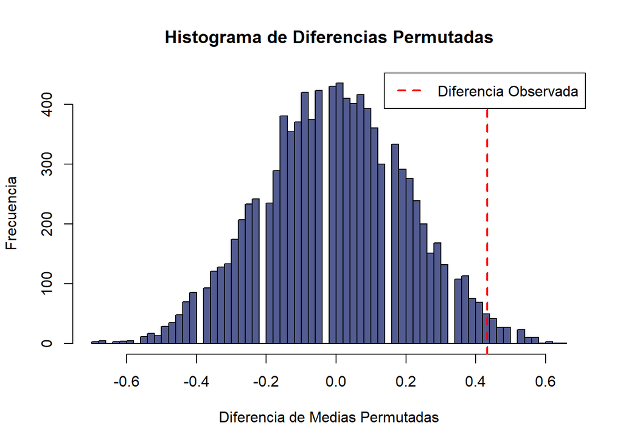

```r
# 0.019


# Graficar el histograma de las diferencias permutadas
hist(diferencias_permutadas,
     breaks = 50,
     col = "#535C91",
     main = "Histograma de Diferencias Permutadas",
     ylab = "Frecuencia",
     xlab = "Diferencia de Medias Permutadas")
abline(v = diferencia_observada, col = "red", lwd = 2, lty = 2)


legend("topright",
       legend = c("Diferencia Observada"),
       col = c("red"),
       lty = c(2),
       lwd = c(2))
```

### 6.3 Conclusión

Ambos métodos, el paramétrico y el no paramétrico, indican que existen diferencias estadísticamente significativas en la longitud hocico-cloaca entre los sexos en la especie de gecko estudiada. Esto presenta evidencia de dimorfismo sexual en cuanto a la longitud hocico-cloaca enesta especie.